# data-analysis

## Data analysis

The main objectives of the analysis will be these:

1. Explore data distributions.
2. Ascertain the relationship between higher education and activity rates.
3. Ascertain the relationship between expenditure on education and teritary (secondary) education.
4. Explore outliers.

### Important note about education attainment

Before we move on there is a definition, that will be very important to this analysis. Education attainment level for a particular education level (for example upper secondary education) means the portion of residents, whose highest level of education is said education level (in our case upper secondary education).

For example a respondent, who has graduated with a bachelors degree will be added to the teritary education attainment level, not to secondary or priamry education attainment levels.

```python
import pandas as pd
import numpy as np
import matplotlib.pyplot as plt
import seaborn as sns
from sklearn.linear_model import LinearRegression
```

```python
sns.set_theme(style='whitegrid')
```

```python
df = pd.read_parquet('output/master_table.parquet')
df.head()
```

|  | Year | Entity code | Education level code | sex | age | Education expenditure (% GDP) | Pupil to student ratio | Activity level | Education attainment |
| --- | --- | --- | --- | --- | --- | --- | --- | --- | --- |
| 0 | 1992 | BE | ED02 | F | Y15-19 | NaN | NaN | 4.5 | NaN |
| 1 | 1992 | BE | ED02 | F | Y15-24 | NaN | NaN | 20.5 | NaN |
| 2 | 1992 | BE | ED02 | F | Y15-39 | NaN | NaN | 44.8 | NaN |
| 3 | 1992 | BE | ED02 | F | Y15-59 | NaN | NaN | 37.8 | NaN |
| 4 | 1992 | BE | ED02 | F | Y15-64 | NaN | NaN | 33.2 | 50.9 |

# Explore

Although this does seem to be to be too mathematical and impractical, but it does shed light on skewness of the data and allows us to make better decisions when doing correlation analysis or outlier detection.

```python
df_melted = df.melt(
    id_vars = ['Year', 'Entity code', 'Education level code', 'sex', 'age'],
    value_vars = ['Education expenditure (% GDP)', 'Pupil to student ratio', 'Activity level', 'Education attainment'],
    var_name="Measure", value_name = "Value"
)
```

### In the following analysis I focus on secondary level education and total age interval (from 15 to 64)

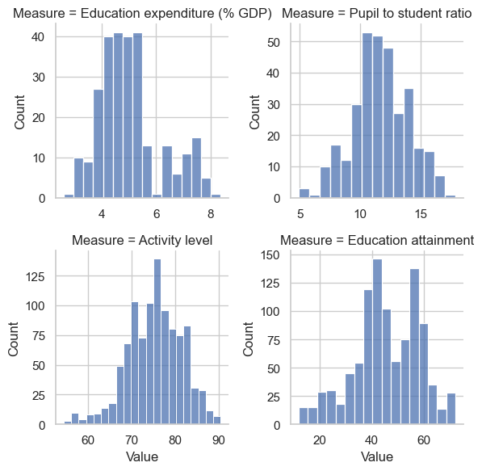

```python
df_slice = df_melted[
    (df_melted['age'] == 'Y15-64') &
    (df_melted['sex'] == 'T') &
    (df_melted['Education level code'] == 'ED34')
]

facet_grid = sns.FacetGrid(
    data=df_slice, col='Measure', col_wrap=2,
    sharex=False, sharey=False
)

facet_grid.map(sns.histplot, "Value")
```

### Interpretation

# Relationship between teritary education and activity rates

1. The relationship between teritary education rates (defined as the percentage of people, whose highest level of education is teritary) and activity rates.
2. The relationship between secondary education rates (defined as the percentage of people, whose highest level of education is secondary) and activity rates.

```python
df_teritary = df[ (df['sex'] == 'T') &
    (df['age'] == 'Y15-64') &
    (df['Education level code'] == 'ED58')]

df_teritary.head()
```

|  | Year | Entity code | Education level code | sex | age | Education expenditure (% GDP) | Pupil to student ratio | Activity level | Education attainment |
| --- | --- | --- | --- | --- | --- | --- | --- | --- | --- |
| 268 | 1992 | BE | ED58 | T | Y15-64 | NaN | NaN | 86.1 | 18.4 |
| 565 | 1992 | DE | ED58 | T | Y15-64 | NaN | NaN | 87.2 | 17.9 |
| 859 | 1992 | DK | ED58 | T | Y15-64 | NaN | NaN | 93.9 | 15.4 |
| 1156 | 1992 | EL | ED58 | T | Y15-64 | NaN | NaN | 82.0 | 10.5 |
| 1453 | 1992 | ES | ED58 | T | Y15-64 | NaN | NaN | 87.6 | 11.1 |

```python
sns.set_theme(style='whitegrid')
```

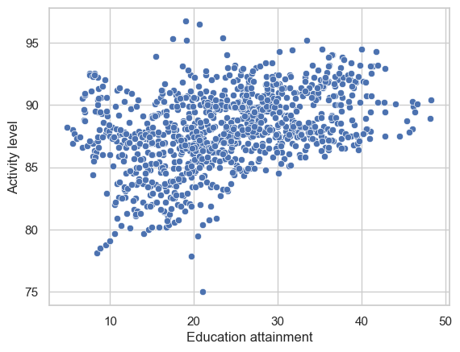

```python
sns.scatterplot(data = df_teritary,
            x = 'Education attainment',
            y = 'Activity level')
```

### Explanation

There seems to be a relationship between teritary education and activity rates. However, it is likely, that both activity levels and people with teritary education are influenced by the economic state of the country. So additional analysis, that would ascertain this possibility would be great.

```python
subset = ['Education attainment', 'Activity level']

corr_val = df_teritary[subset]\
    .corr(method="spearman")\
    .iloc[0,1] # Get the correlation from correlation matrix
```

```python
from IPython import display
```

```python
display.Markdown(f"### The Spearman correlation coefficient is {corr_val:.3f}")
```

The Spearman correlation coefficient is 0.411

### Explanation

The Spearman correlation was picked since it is more robust to outliers.

0.411 shows, that the correlation is medium at best, however to check, whether it is insgnifcant, in a longer project, I would use Spearmann's correlation test.

```python
df_secondary = df[ (df['sex'] == 'T') &
    (df['age'] == 'Y15-64') &
    (df['Education level code'] == 'ED34')]

df_secondary.head()
```

|  | Year | Entity code | Education level code | sex | age | Education expenditure (% GDP) | Pupil to student ratio | Activity level | Education attainment |
| --- | --- | --- | --- | --- | --- | --- | --- | --- | --- |
| 169 | 1992 | BE | ED34 | T | Y15-64 | NaN | NaN | 66.8 | 32.0 |
| 466 | 1992 | DE | ED34 | T | Y15-64 | NaN | NaN | 75.3 | 57.8 |
| 763 | 1992 | DK | ED34 | T | Y15-64 | NaN | NaN | 86.6 | 52.6 |
| 1057 | 1992 | EL | ED34 | T | Y15-64 | NaN | NaN | 59.9 | 28.5 |
| 1354 | 1992 | ES | ED34 | T | Y15-64 | NaN | NaN | 54.4 | 16.9 |

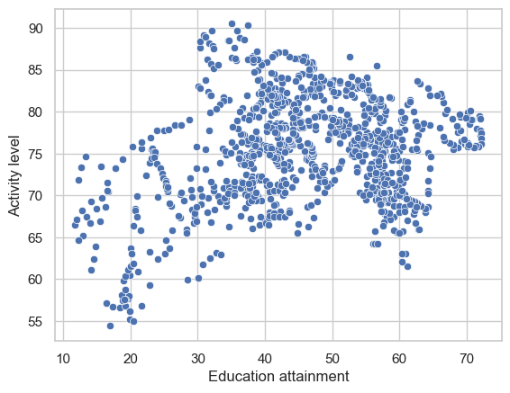

```python
sns.scatterplot(data = df_secondary,
            x = 'Education attainment',
            y = 'Activity level')
```

### Explanation

There seems to be a less apparent relationship between secondary education and activity rates. It would be safe to say, that **activity rates correlate more with teritary education rates than with secondary**.

```python
subset = ['Education attainment', 'Activity level']

corr_val = df_secondary[subset]\
    .corr(method="spearman")\
    .iloc[0,1] # Get the correlation from correlation matrix

display.Markdown(f"### The Spearman correlation coefficient is {corr_val:.3f}")
```

The Spearman correlation coefficient is 0.138

### Explanation

0.138 shows, that the correlation is very small. However to check, whether it is insgnifcant, in a longer project, I would use Spearmann's correlation test.

# Relationship between expenditure and teritary (secondary) education rates

```python
mask = (df['sex'] == 'T') & (df['age'] == 'Y15-64')
subset = ['Education level code', 'Education expenditure (% GDP)', 'Education attainment']

df_expenditure = df[mask][subset].dropna()
```

```python
education_codes = pd.read_parquet('output/education_code_tbl.parquet')

def get_edu_code(code: str):
    mask = education_codes['edu_code'] == code

    level = education_codes[mask]['Education level']

    return level.values[0]
```

```python
df_expenditure['Education level'] = df_expenditure['Education level code'].map(get_edu_code)
df_expenditure.head()
```

|  | Education level code | Education expenditure (% GDP) | Education attainment | Education level |
| --- | --- | --- | --- | --- |
| 180894 | ED02 | 5.54711 | 22.2 | Less than primary, primary and lower secondary... |
| 180999 | ED34 | 5.54711 | 60.2 | Upper secondary and post-secondary non-tertiar... |
| 181101 | ED58 | 5.54711 | 17.7 | Tertiary education (levels 5-8) |
| 181211 | ED02 | 6.63053 | 30.4 | Less than primary, primary and lower secondary... |
| 181316 | ED34 | 6.63053 | 38.1 | Upper secondary and post-secondary non-tertiar... |

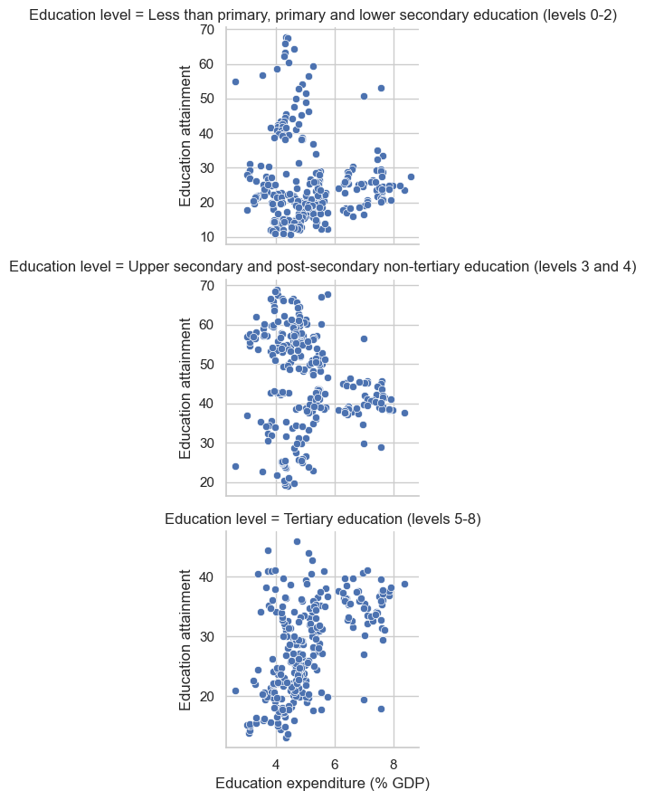

```python
grid = sns.FacetGrid(
    row = 'Education level',
    sharey=False,
    data=df_expenditure
)
grid.map(sns.scatterplot, 'Education expenditure (% GDP)', 'Education attainment',)
```

# Explanation

It is hard to ascertain, whether education expenditure influences lower education and secondary education rates since the number of outliers is quite big. It does seem, that higher education expenditure may influence teritary education attainment rate, however further correlation analysis is required.

```python
df_expenditure.groupby('Education level')\
    [['Education expenditure (% GDP)', 'Education attainment']]\
    .corr(method="spearman")
```

| Education level |  | Education expenditure (% GDP) | Education attainment |
| --- | --- | --- | --- |
| Less than primary, primary and lower secondary education (levels 0-2) | Education expenditure (% GDP) | 1.000000 | 0.026956 |
|  | Education attainment | 0.026956 | 1.000000 |
| Tertiary education (levels 5-8) | Education expenditure (% GDP) | 1.000000 | 0.512529 |
|  | Education attainment | 0.512529 | 1.000000 |
| Upper secondary and post-secondary non-tertiary education (levels 3 and 4) | Education expenditure (% GDP) | 1.000000 | -0.254513 |
|  | Education attainment | -0.254513 | 1.000000 |

# Explanation

# Outliers

To take in consideration the limits of this analysis, I will detect outliers only under one dimension slice (it is possible to detect outliers for each possible dimension configuration or a bigger subset of them). The most important slice, in my opinion, is: `sex=Total`, `Educational level code = ED34` (secondary education) and `age=Y15-64` slice.

For outlier detection I will use simple quartile method.

Outliers are identified using limits calculated from the quartiles. Any data point falling below `Q1 - 1.5×IQR` or above `Q3 + 1.5×IQR` is considered an outlier. Some applications also define extreme outliers using a `3.0×IQR` multiplier instead of `1.5×IQR` for more stringent detection.

> For further analysis I will need to be able to conviently get country names.

```python
country_names = pd.read_parquet('output/dimension_tbl_geo.parquet')
country_names = country_names.rename(
    columns={'entity': 'Entity code', 'Entity name': 'Country'}
).drop( columns=['Latitude', 'Longitude'] )
```

```python
df_country = df.merge(country_names, on=['Entity code'])\
    .drop(columns=['Entity code'])

df_country
```

|  | Year | Education level code | sex | age | Education expenditure (% GDP) | Pupil to student ratio | Activity level | Education attainment | Country |
| --- | --- | --- | --- | --- | --- | --- | --- | --- | --- |
| 0 | 1992 | ED02 | F | Y15-19 | NaN | NaN | 4.5 | NaN | Belgium |
| 1 | 1992 | ED02 | F | Y15-24 | NaN | NaN | 20.5 | NaN | Belgium |
| 2 | 1992 | ED02 | F | Y15-39 | NaN | NaN | 44.8 | NaN | Belgium |
| 3 | 1992 | ED02 | F | Y15-59 | NaN | NaN | 37.8 | NaN | Belgium |
| 4 | 1992 | ED02 | F | Y15-64 | NaN | NaN | 33.2 | 50.9 | Belgium |
| ... | ... | ... | ... | ... | ... | ... | ... | ... | ... |
| 282602 | 2024 | ED58 | T | Y65-74 | NaN | NaN | 20.0 | NaN | Türkiye |
| 282603 | 2024 | ED58 | T | Y70-74 | NaN | NaN | 16.3 | NaN | Türkiye |
| 282604 | 2024 | None | None | None | 3.155044 | NaN | NaN | NaN | Tanzania, United Republic of |
| 282605 | 2024 | None | None | None | 5.456166 | NaN | NaN | NaN | Samoa |
| 282606 | 2024 | None | None | None | 6.720073 | NaN | NaN | NaN | South Africa |

282607 rows × 9 columns

### Outlier calculations

```python
mask = ( (df_country['sex'] == 'T') & \
    (df_country['Education level code'] == 'ED34') & \
    (df_country['age'] == 'Y15-64') )

subset = ['Education expenditure (% GDP)', 'Pupil to student ratio',
          'Activity level', 'Education attainment']
df_slice = df_country[mask][subset]
```

```python
def get_limits(values):
    mask = ~np.isnan(values)
    values_clean = values[mask]

    q3, q1 = np.quantile(values_clean, [0.75, 0.25])
    iqr = q3 - q1

    return q3 + 1.5 * iqr, q1 - 1.5 * iqr
```

```python
outliers = []
for col in subset:
    upper, lower = get_limits( df_slice[col].values )

    mask = (df_slice[col] < lower) | (df_slice[col] > upper)

    outliers.append(df_slice[mask].index)
```

```python
outliers
```

```
[Index([167485, 168121, 169696, 173220, 178304, 179882, 188479, 190055, 193579,
        198661, 200236, 208839, 219022, 220598, 229199, 230776, 234295, 239372,
        240953, 251132],
       dtype='int64'),
 Index([166538, 168755, 178939, 271772], dtype='int64'),
 Index([  1057,   3427,   6094,   9055,  12926,  17963, 100396, 110227, 120078,
        129929, 140106, 160483, 241908],
       dtype='int64'),
 Index([], dtype='int64')]
```

### Education expenditure outliers

```python
df_country.iloc[outliers[0], :].head()
```

|  | Year | Education level code | sex | age | Education expenditure (% GDP) | Pupil to student ratio | Activity level | Education attainment | Country |
| --- | --- | --- | --- | --- | --- | --- | --- | --- | --- |
| 167485 | 2013 | ED34 | T | Y15-64 | 7.57924 | 8.3 | 72.1 | 28.9 | Malta |
| 168121 | 2013 | ED34 | T | Y15-64 | 7.43906 | 10.3 | 81.8 | 42.2 | Norway |
| 169696 | 2013 | ED34 | T | Y15-64 | 7.61121 | 13.0 | 86.6 | 45.7 | Sweden |
| 173220 | 2014 | ED34 | T | Y15-64 | 7.63485 | 11.1 | 81.1 | 41.9 | Denmark |
| 178304 | 2014 | ED34 | T | Y15-64 | 7.64403 | NaN | 81.1 | 39.3 | Norway |

```python
df_country.iloc[outliers[0], :].value_counts('Country')
```

```
Country
Sweden     8
Norway     8
Denmark    3
Malta      1
Name: count, dtype: int64
```

Above is the number of outliers from each country (their code). SE - Sweden, NO - Norway, DK - Denmark, MT - Malta

## Further inquiry

On this outlier list we can see nordic countries - that is not something unexpected. However, what is unexpected is that Malta is part of the list.

1. Malta is a small island, that does not have much resources, so it relies on human capital.
2. There are a lot of foreign students and around [2013 they had a surge of foreign students.](https://spunt.mt/what-maltas-education-system-learn-from-the-estonia/)
3. Malta was in recovery mode after austerity caused by the 2008 crisis.

Thus Maltese policy makers decided to increase spending in education.

### Pupil to teacher ratio outliers

```python
len(outliers[1])
```

```
4
```

```python
df_country.iloc[outliers[1], :].head()
```

|  | Year | Education level code | sex | age | Education expenditure (% GDP) | Pupil to student ratio | Activity level | Education attainment | Country |
| --- | --- | --- | --- | --- | --- | --- | --- | --- | --- |
| 166538 | 2013 | ED34 | T | Y15-64 | 4.680668 | 5.1 | 69.4 | 38.6 | Luxembourg |
| 168755 | 2013 | ED34 | T | Y15-64 | 5.270970 | 4.9 | 76.9 | 23.0 | Portugal |
| 178939 | 2014 | ED34 | T | Y15-64 | 5.124000 | 5.4 | 77.8 | 23.9 | Portugal |
| 271772 | 2023 | ED34 | T | Y15-64 | NaN | 17.9 | 76.9 | 53.8 | Slovenia |

```python
df_country.iloc[outliers[1], :].value_counts('Country')
```

```
Country
Portugal      2
Luxembourg    1
Slovenia      1
Name: count, dtype: int64
```

## Further inquiry, context

Now, we have small pupil to teacher ratios for Portugal and Luxembourg. However Slovenia in 2023 had an irregularly large pupil to teacher ratio.

> To limit the scope of this analysis I will limit myself to Slovenia only.

The main culprit, that influence this unfortunate statistic seems to be [teacher shortage](https://op.europa.eu/webpub/eac/education-and-training-monitor/en/country-reports/slovenia.html) caused by small pay (comparatively) of [1500-2400 euros gross](https://www.boljsaplaca.si/en/salaryinfo/education-science-research/secondary-school-teacher).

### Activity level outliers

```python
df_country.iloc[outliers[2], :].head()
```

|  | Year | Education level code | sex | age | Education expenditure (% GDP) | Pupil to student ratio | Activity level | Education attainment | Country |
| --- | --- | --- | --- | --- | --- | --- | --- | --- | --- |
| 1057 | 1992 | ED34 | T | Y15-64 | NaN | NaN | 54.4 | 16.9 | Spain |
| 3427 | 1993 | ED34 | T | Y15-64 | NaN | NaN | 57.1 | 16.4 | Spain |
| 6094 | 1994 | ED34 | T | Y15-64 | NaN | NaN | 56.7 | 17.4 | Spain |
| 9055 | 1995 | ED34 | T | Y15-64 | NaN | NaN | 56.6 | 18.4 | Spain |
| 12926 | 1996 | ED34 | T | Y15-64 | NaN | NaN | 56.8 | 19.2 | Spain |

```python
df_country.iloc[outliers[2], :].value_counts("Country")
```

```
Country
Türkiye    7
Spain      6
Name: count, dtype: int64
```

### Context

# Summary